# Reproducible Research: Peer Assessment 1

## Imputing missing values

There are missing values in the data, which have been thusfar simply excluded.  
Now we will use the strong autocorrelation of the data and as the imputed value for each missing value we will use the latest observed value. Since the first value might also be missing we will set that to the average value for that interval, which was calculated previously.

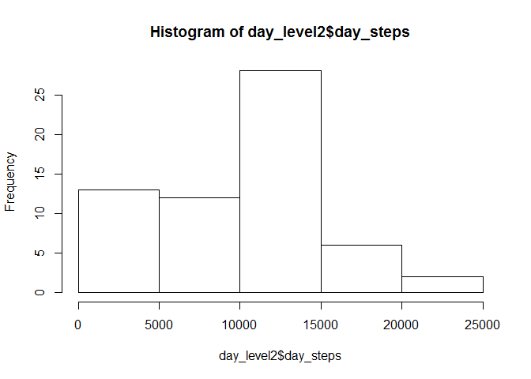

```r
# New dataset
activity_new<- activity
autocorrelation <- acf(activity_new$steps[!is.na(activity_new$steps)],lag=1,plot=FALSE)$acf[2,1,1]
NA_count <- sum(is.na(activity_new$steps))

# Imputation
if(is.na(activity_new$steps[1])){
    activity_new$steps[1] <- interval_level$inter_steps[interval_level$interval==activity_new$interval[1]]
}
for(row in 2:nrow(activity_new)){
    if(is.na(activity_new$steps[row])) activity_new$steps[row] <- activity_new$steps[(row-1)]
}

# Calculate again day_level
day_level2 <- activity_new %>%
    group_by(date) %>%
    summarize(day_steps = sum(steps,na.rm=TRUE),valid_times=sum(!is.na(steps))) %>%
    filter(valid_times>0)
hist(day_level2$day_steps)
```

```r
meanSteps2 <- round(mean(day_level2$day_steps),0)
medianSteps2 <- median(day_level2$day_steps)
difMean <- meanSteps - meanSteps2
difMedian <- medianSteps - medianSteps2
```

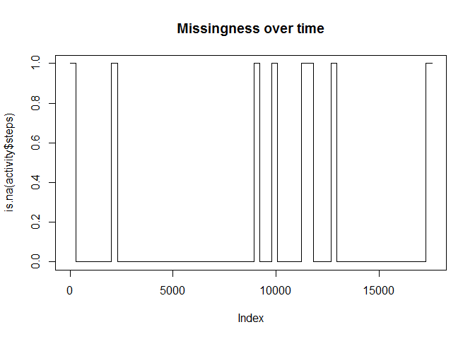

```r
# There seems to be a few times of prolonged periods of missing values
plot(is.na(activity$steps),type="l",main="Missingness over time")
```

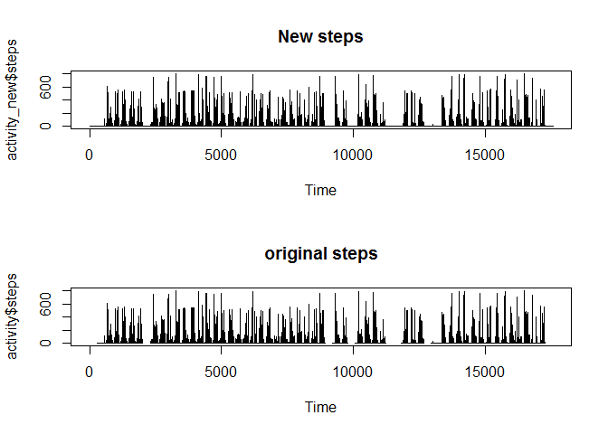

```r
# The imputed values seem to fall quite nicely in the data
par(mfrow=c(2,1))
plot.ts(activity_new$steps,main="New steps")
plot.ts(activity$steps,main="original steps")
```

The data and missingness structure makes one wonder if the longer periods of missingness are actually e.g. sleeping, and thus imputing zero steps for those intervals would be even more justified.

## Are there differences in activity patterns between weekdays and weekends?

The activity pattern seems to be very different between weekends and weekdays.

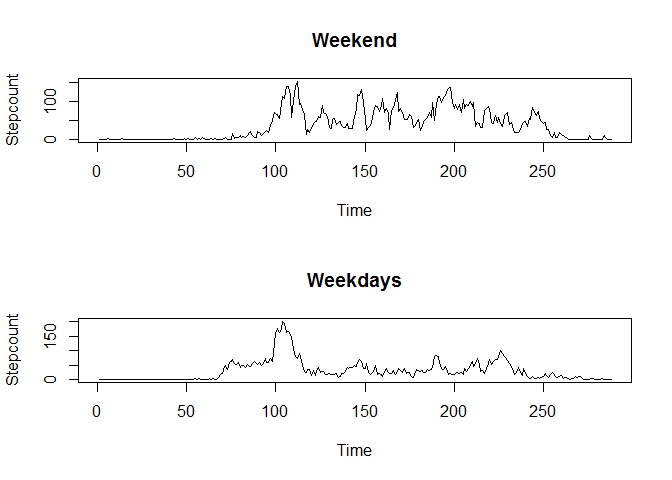

```r
activity_new$weekend <- as.POSIXlt(activity_new$date)$wday
activity_new$weekend <- activity_new$weekend %in% c(0,6)
activity_new$weekend <- as.factor(activity_new$weekend)
weekend <- activity_new %>%
    group_by(weekend,interval) %>%
    summarize(mean_steps = mean(steps))
par(mfrow=c(2,1))
plot.ts(weekend$mean_steps[weekend$weekend=="TRUE"],main="Weekend",ylab="Stepcount")
plot.ts(weekend$mean_steps[weekend$weekend=="FALSE"],main="Weekdays",ylab="Stepcount")
```